# evapoRe| evapotranspiration R Recipes

Akbar Rahmati Ziveh, Mijael Rodrigo Vargas Godoy, Vishal Thakur, Yannis markonis

2023-06-09

The `evapoRe` package is a complementary tool to the `pRecipe` package, developed as part of the ITHACA project at the Faculty of Environmental Sciences, Czech University of Life Sciences Prague, Czechia. Its primary purpose is to facilitate the download, exploration, visualization, and analysis of evapotranspiration (ET) data. Additionally, evapoRe offers the functionality to calculate various potential evapotranspiration (PET) methods.

~*The Global Water Cycle Budget* | Vargas Godoy et al. (2021)

*“Like civilization and technology, our understanding of the global water cycle has been continuously evolving, and we have adapted our quantification methods to better exploit new technological resources. The accurate quantification of global water fluxes and storage is crucial in studying the global water cycle.”*

## Before We Start

Like many other R packages, `evapoRe` has some system requirements:

- [PROJ](https://proj.org/download.html)
- Geospatial Data Abstraction Library [(GDAL)](https://gdal.org/download.html)
- Network Common Data Form [(NetCDF)](https://www.unidata.ucar.edu/software/netcdf/)

## Data

`evapoRe` database hosts 10 different ET data sets; one satellite-based, four reanalysis, and five hydrological model products. Their native specifications, as well as links to their providers, and their respective references are detailed in the following subsections. We have already homogenized, compacted to a single file, and stored them in a [Zenodo repository](https://doi.org/10.5281/zenodo.7990413) under the following naming convention:

`<data set>_<variable>_<units>_<coverage>_<start date>_<end date>_<resolution>_<time step>.nc`

The `evapoRe` data collection was homogenized to these specifications: * `<variable>` = Actual evapotranspiration (e) * `<units>` = millimeters (mm) * `<resolution>` = 0.25° * `<time step>` = monthly

E.g., ERA5 (Hersbach et al. 2020) would be:

`era5_e_mm_global_195901_202112_025_monthly.nc`

### Satellite-Based Products

| Data Set | Spatial Resolution | Spatial Coverage Global | Spatial Coverage Land | Spatial Coverage Ocean | Temporal Resolution | Record Length | Get Data | Reference |
| --- | --- | --- | --- | --- | --- | --- | --- | --- |
| GLEAM V3.0 | 0.25° |  | x |  | Monthly | 1980/01-2021/12 | [Download](https://www.gleam.eu/) | Martens et al. (2017) |

### Reanalysis Products

| Data Set | Spatial Resolution | Spatial Coverage Global | Spatial Coverage Land | Spatial Coverage Ocean | Temporal Resolution | Record Length | Get Data | Reference |
| --- | --- | --- | --- | --- | --- | --- | --- | --- |
| ERA5-Land | 0.1° |  | x |  | Monthly | 1960/01-2022/12 | [Download](https://cds.climate.copernicus.eu/cdsapp#!/dataset/reanalysis-era5-land-monthly-means?tab=form) | Muñoz-Sabater et al. (2021) |
| ERA5 | 0.25° | x | x | x | Monthly | 1959/01-2021/12 | [Download](https://cds.climate.copernicus.eu/cdsapp#!/dataset/reanalysis-era5-single-levels-monthly-means?tab=overview) | Hersbach et al. (2020) |
| JRA-55 | 1.25° |  | x |  | Monthly | 1958/01-2021/12 | [Download](https://rda.ucar.edu/datasets/ds628.1/dataaccess/) | Kobayashi et al. (2015) |
| MERRA-2 | 0.5° x 0.625° |  | x |  | Monthly | 1980/01-2023/01 | [Download](https://disc.gsfc.nasa.gov/datasets?page=1&project=MERRA-2) | Gelaro et al. (2017) |

### Hydrological Model Forcing

| Data Set | Spatial Resolution | Spatial Coverage Global | Spatial Coverage Land | Spatial Coverage Ocean | Temporal Resolution | Record Length | Get Data | Reference |
| --- | --- | --- | --- | --- | --- | --- | --- | --- |
| FLDAS | 0.1° |  | x |  | Monthly | 1982/01-2022/12 | [Download](https://ldas.gsfc.nasa.gov/fldas/fldas-data-download) | McNally et al. (2017) |
| GLDAS CLSM V2.1 | 1° |  | x |  | Monthly | 2000/01-2022/11 | [Download](https://ldas.gsfc.nasa.gov/gldas/gldas-get-data) | Rodell et al. (2004) |
| GLDAS NOAH V2.1 | 0.25° |  | x |  | Monthly | 2000/01-2022/11 | [Download](https://ldas.gsfc.nasa.gov/gldas/gldas-get-data) | Rodell et al. (2004) and Beaudoing and Rodell (2020) |
| GLDAS VIC V2.1 | 1° |  | x |  | Monthly | 2000/01-2022/11 | [Download](https://ldas.gsfc.nasa.gov/gldas/gldas-get-data) | Rodell et al. (2004) |
| TerraClimate | 4$km$ |  | x |  | Monthly | 1958/01-2021/12 | [Download](https://www.climatologylab.org/terraclimate.html) | Abatzoglou et al. (2018) |

# Recipe

In this introductory recipe we will first download the FLDAS data set. We will then subset the downloaded data over Central Europe for the 2001-2010 period, and crop it to the national scale for Czechia. In the next step, we will generate time series for our data sets and conclude with the visualization of our data.

**NOTE:** While the functions in `evapoRe` are intended to work directly with its data inventory. It can handle most other ET data sets in “.nc” format, as well as any other “.nc” file generated by its functions.

## Installation

```r
devtools::install_github("AkbarR1184/evapoRe")
library(evapoRe)
```

## Download

Downloading the entire data collection or only a few data sets is quite straightforward. You just call the `download_data` function, which has four arguments *name*, *destination*, *domain*, and *time_res*.

- *name* is set to “all” by default, but you can specify the names of your data sets of interest only.
- *destination* is set to “.” by default. I.e., the current working directory. By replacing it for [your_project_folder], the downloaded files will be stored in [your_project_folder] instead.
- *domain* is set to “raw” by default, but you can specify the domain of your interest only. E.g., “ocean” for ocean only data sets (For availability please check the Data section).
- *time_res* is set to “monthly” by default, but if you prefer you can also download annual data with “yearly”.

Let’s download the fldas data set and inspect its content with `show_info`:

```r
download_data(name = 'fldas')
fldas_global <- raster::brick('fldas_e_mm_land_198201_202212_025_monthly.nc')
show_info(fldas_global)
```

```
[1] "class      : RasterBrick "
[2] "dimensions : 720, 1440, 1036800, 492  (nrow, ncol, ncell, nlayers)"
[3] "resolution : 0.25, 0.25  (x, y)"
[4] "extent     : -180, 180, -90, 90  (xmin, xmax, ymin, ymax)"
[5] "crs        : +proj=longlat +datum=WGS84 "
[6] "source     : fldas_e_mm_land_198201_202212_025_monthly.nc "
[7] "names      : X1982.01.01, X1982.02.01, X1982.03.01, X1982.04.01, X1982.05.01, X1982.06.01, X1982.07.01, X1982.08.01, X1982.09.01, X1982.10.01, X1982.11.01, X1982.12.01, X1983.01.01, X1983.02.01, X1983.03.01, ... "
[8] "Date/time  : 1982-01-01, 2022-12-01 (min, max)"
[9] "varname    : e "
```

## Processing

Once we have downloaded our database, we can start processing the data with:

- `subset_spacetime` to subset the data in time and space.
- `subset_space` to subset the data to the region of interest.
- `subset_time` to select the years of interest.
- `mon_to_year` to aggregate the data from monthly into annual.
- `rescale_data` to go from the native resolution (0.25°) to coarser ones (e.g., 0.5°, 1°, 1.5°, 2°, etc).
- `make_ts` to generate a time series by taking the area weighted average over each time step.

### Subset

To subset our data to a desired region and period of interest, we use the `subset_spacetime` function, which has four arguments *data*, *years*, *bbox*, and *autosave*.

- *data* is the path to the data set of interest or a RasterBrick object.
- *years* is the period of interest in the form (start_year, end_year)
- *bbox* is the bounding box of the region of interest with the coordinates in degrees in the form (xmin, xmax, ymin, ymax).
- *autosave* is set to FALSE by default. If TRUE data will be automatically stored in the same location of the input file.

```r
fldas_subset <- subset_spacetime(fldas_global, years = c(2001, 2010), bbox = c(2,28,42,58))
show_info(fldas_subset)
```

```
[1] "class      : RasterBrick "
[2] "dimensions : 64, 104, 6656, 120  (nrow, ncol, ncell, nlayers)"
[3] "resolution : 0.25, 0.25  (x, y)"
[4] "extent     : 2, 28, 42, 58  (xmin, xmax, ymin, ymax)"
[5] "crs        : +proj=longlat +datum=WGS84 "
[6] "source     : memory"
[7] "names      :  X2001.01.01,  X2001.02.01,  X2001.03.01,  X2001.04.01,  X2001.05.01,  X2001.06.01,  X2001.07.01,  X2001.08.01,  X2001.09.01,  X2001.10.01,  X2001.11.01,  X2001.12.01,  X2002.01.01,  X2002.02.01,  X2002.03.01, ... "
[8] "min values : -3.7794194221, -0.4208407104, -0.5045991540, -0.0572454371, -0.0005709816,  0.0000000000,  0.0000000000,  0.0000000000, -0.3487000465, -1.6532191038, -0.4017279446, -2.5777058601, -2.6171388626, -0.3143836856, -0.2774783075, ... "
[9] "max values :      56.90099,      69.52248,     113.14240,     125.60358,     174.75136,     190.40407,     189.30975,     155.39180,      99.69257,      76.16212,      62.63054,      47.89834,      40.91222,      68.70403,      99.67541, ... "
[10] "time       : 2001-01-01, 2010-12-01 (min, max)"
```

### Crop

To further crop our data to a desired polygon other than a rectangle, we use the `crop_data` function, which has three arguments *x*, *shp_path*, *autosave*.

- *x* is the path to a “.nc” data set file or a RasterBrick object.
- *shp_path* is the path to a “.shp” file that we want to use to crop our data.
- *autosave* is set to FALSE by default. If TRUE data will be automatically stored in the same location of the input file.

Let’s crop our fldas subset to cover only Czechia with the respective [shape file](https://geodata.ucdavis.edu/gadm/gadm4.1/shp/gadm41_CZE_shp.zip), and inspect its content with `show_info`:

```r
fldas_cz <- crop_data(x = fldas_cz, shp_path = "gadm41_CZE_0.shp")
show_info(fldas_cz)
```

[output not shown]

### PET calculation

First we need to download temperature data. To to this we will use terraclimate temperature data from the [Zenodo repository](https://doi.org/10.5281/zenodo.7990413):

*variable* is the variable name in which `t` stands for tavg, tmin, and tmax.

```r
download_terraclimate(variable = "t", folder_path = ".")
```

This will returns terraclimate temperature data in following name convention e.g.,

`terraclimate_tavg_land_19580101_20221231_025_monthly.nc`

`pet_calc` function is calculating PET from various PET *method*. “hs” for Hargreaves Samani method (Hargreaves and Samani 1982), “od” for Oudin method (Oudin et al. 2005), “mb” for McGuinness and Bordne method (McGuinness and Bordne 1972), “jh” for Jensen Haise method (Jensen and Haise 1963), and “br” for Baier and Robertson (Baier and Robertson 1965).

#### Calculate PET by Oudin method

```r
tavg_brick <- raster::brick("terraclimate_tavg_land_19580101_20221231_025_monthly.nc")
pet_Oudin<- pet_calc(method = "od", tavg = tavg_brick)
show_info(pet_Oudin)
```

### Generate Time series

To make a time series out of our data, we use the `make_ts` function, which has three arguments *data*, *name*, and *autosave*.

- *data* is the path to a “.nc” data set file or a RasterBrick object.
- *name* is the short name of a data set. E.g., ‘fldas’.
- *autosave* is set to FALSE by default. If TRUE data will be automatically stored in the same location of the input file.

Let’s generate the time series for our three different fldas data sets (Global, Central Europe, and Czechia), and inspect its first 12 rows:

```r
fldas_global_ts <- make_ts(fldas_global)
head(fldas_global_ts, 12)
```

```
          date    value name type
 1: 1982-01-01 40.01818   NA   NA
 2: 1982-02-01 39.05691   NA   NA
 3: 1982-03-01 45.63258   NA   NA
 4: 1982-04-01 48.38817   NA   NA
 5: 1982-05-01 56.04541   NA   NA
 6: 1982-06-01 59.48527   NA   NA
 7: 1982-07-01 63.42378   NA   NA
 8: 1982-08-01 58.08678   NA   NA
 9: 1982-09-01 47.53051   NA   NA
10: 1982-10-01 43.30959   NA   NA
11: 1982-11-01 39.14826   NA   NA
12: 1982-12-01 39.41859   NA   NA
```

```r
fldas_subset_ts <- make_ts(fldas_subset)
head(fldas_subset_ts, 12)
```

```
          date     value name type
 1: 2001-01-01  14.47523   NA   NA
 2: 2001-02-01  24.55700   NA   NA
 3: 2001-03-01  43.77176   NA   NA
 4: 2001-04-01  61.23033   NA   NA
 5: 2001-05-01 112.55881   NA   NA
 6: 2001-06-01 114.57058   NA   NA
 7: 2001-07-01 116.47619   NA   NA
 8: 2001-08-01  79.83941   NA   NA
 9: 2001-09-01  50.78079   NA   NA
10: 2001-10-01  32.62168   NA   NA
11: 2001-11-01  20.41700   NA   NA
12: 2001-12-01  13.59456   NA   NA
```

```r
fldas_cz_ts <- make_ts(fldas_cz)
head(fldas_cz_ts, 12)
```

```
          date     value name type
 1: 2001-01-01  12.23963   NA   NA
 2: 2001-02-01  23.80942   NA   NA
 3: 2001-03-01  36.08155   NA   NA
 4: 2001-04-01  50.36031   NA   NA
 5: 2001-05-01 105.76477   NA   NA
 6: 2001-06-01  95.73339   NA   NA
 7: 2001-07-01  99.95880   NA   NA
 8: 2001-08-01  80.05314   NA   NA
 9: 2001-09-01  42.28572   NA   NA
10: 2001-10-01  24.04546   NA   NA
11: 2001-11-01  15.01222   NA   NA
12: 2001-12-01  12.39291   NA   NA
```

## Visualize

Either after we have processed our data as required or right after downloaded, we have six different options to visualize our data for more information refer to [visualisation section of pRecipe](https://cran.r-project.org/web/packages/pRecipe/vignettes/pRecipe.html#visualize):

### Maps

To see a map of any data set raw or processed, we use `plot_map` which takes only one layer of the RasterBrick as input.

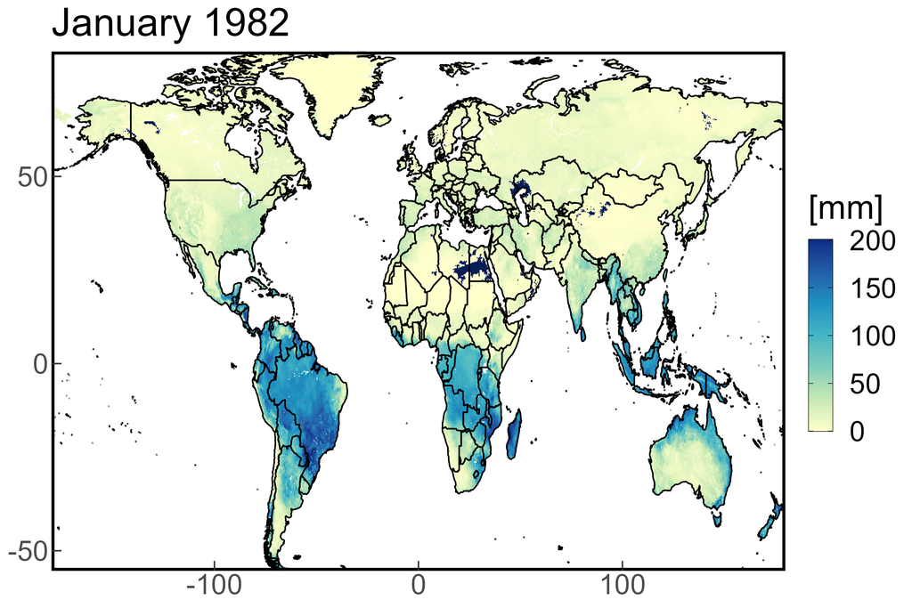

```r
plot_map(fldas_global[[1]])
```

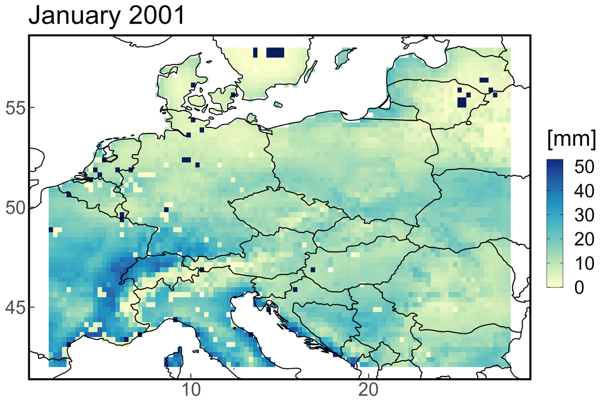

```r
plot_map(fldas_subset[[1]])
```

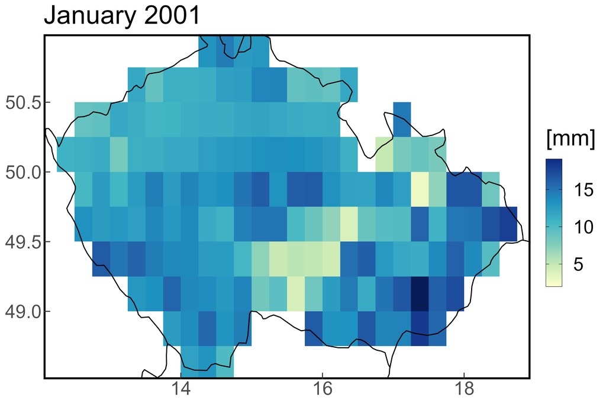

```r
plot_map(fldas_cz[[1]])
```

### Time Series Visuals

To draw a time series generated by `make_ts`, we use any of the options below, which takes only a `make_ts` “.csv” generated file.

#### Lineplots

```r
plot_line(fldas_global_ts)
plot_line(fldas_subset_ts)
plot_line(fldas_cz_ts)
```

[output not shown]

#### Heatmap

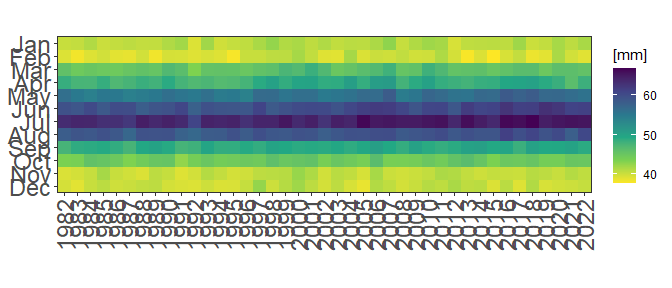

```r
plot_heatmap(fldas_global_ts)
```

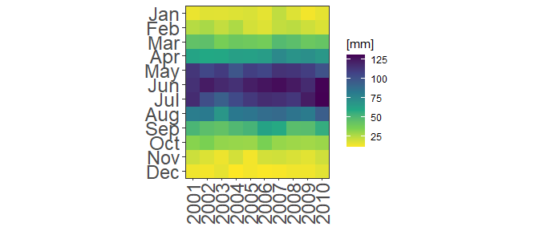

```r
plot_heatmap(fldas_subset_ts)
```

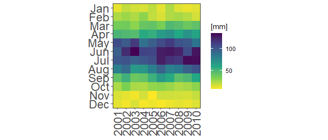

```r
plot_heatmap(fldas_cz_ts)
```

#### Boxplot

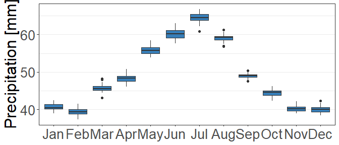

```r
plot_box(fldas_global_ts)
```

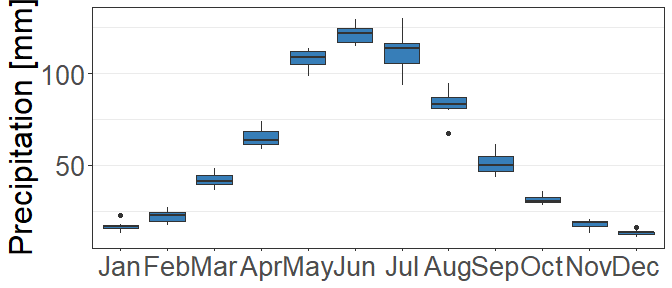

```r
plot_box(fldas_subset_ts)
```

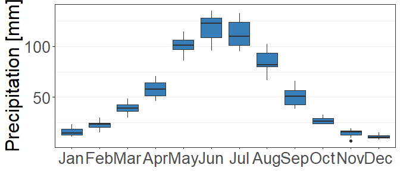

```r
plot_box(fldas_cz_ts)
```

#### Density plots

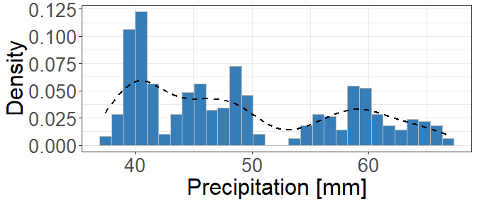

```r
plot_density(fldas_global_ts)
```

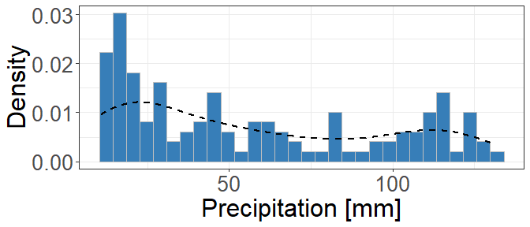

```r
plot_density(fldas_subset_ts)
```

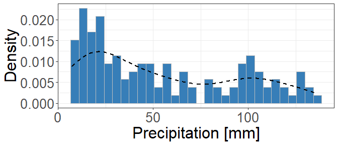

```r
plot_density(fldas_cz_ts)
```

#### Summary

**NOTE:** For good aesthetics we recommend saving `plot_summary` with `ggsave(<filename>, <plot>, width = 16.3, height = 15.03)`.

```r
plot_summary(fldas_global_ts)
#plot_summary(fldas_subset_ts)
#plot_summary(fldas_cz_ts)
```

[figure not shown]

# Coming Soon

we will introduce significant enhancements to ET database and PET calculation methods. This expansion builds upon our existing temperature-based approach and incorporates a radiation-based PET calculation methods, along with an expanded range of temperature-based methods. Our aim is to provide users with a more comprehensive and accurate estimation of ET and PET, catering to a broader range of applications and requirements.

# References

Abatzoglou, John T, Solomon Z Dobrowski, Sean A Parks, and Katherine C Hegewisch. 2018. “TerraClimate, a High-Resolution Global Dataset of Monthly Climate and Climatic Water Balance from 1958–2015.” *Scientific Data* 5 (1): 1–12.

Baier, W., and G. W. Robertson. 1965. “Estimation of Latent Evaporation from Simple Weather Observations.” *Canadian Journal of Plant Science* 45 (3): 276–84.

Beaudoing, Hiroko, and Matthew Rodell. 2020. “GLDAS Noah Land Surface Model L4 monthly 0.25 x 0.25 degree V2.1.” Greenbelt, Maryland, USA: Goddard Earth Sciences Data and Information Services Center (GES DISC). https://doi.org/10.5067/SXAVCZFAQLNO.

Gelaro, Ronald, Will McCarty, Max J. Suárez, Ricardo Todling, Andrea Molod, Lawrence Takacs, Cynthia A. Randles, et al. 2017. “The Modern-Era Retrospective Analysis for Research and Applications, Version 2 (MERRA-2).” *Journal of Climate* 30 (14): 5419–54. https://doi.org/10.1175/JCLI-D-16-0758.1.

Hargreaves, G. H., and Z. A. Samani. 1982. “Estimating Potential Evapotranspiration.” *Journal of the Irrigation and Drainage Division* 108 (3): 225–30.

Hersbach, Hans, Bill Bell, Paul Berrisford, Shoji Hirahara, András Horányi, Joaquín Muñoz-Sabater, Julien Nicolas, et al. 2020. “The ERA5 Global Reanalysis.” *Quarterly Journal of the Royal Meteorological Society* 146 (730): 1999–2049.

Jensen, M. E., and H. R. Haise. 1963. “Estimating Evapotranspiration from Solar Radiation.” *Journal of the Irrigation and Drainage Division* 89 (4): 15–41.

Kobayashi, Shinya, Yukinari Ota, Yayoi Harada, Ayataka Ebita, Masami Moriya, Hirokatsu Onoda, Kazutoshi Onogi, et al. 2015. “The JRA-55 Reanalysis: General Specifications and Basic Characteristics.” *Journal of the Meteorological Society of Japan. Ser. II* 93 (1): 5–48. https://doi.org/10.2151/jmsj.2015-001.

Martens, Brecht, Diego G. Miralles, Hans Lievens, Robin van der Schalie, Richard A. M. de Jeu, Diego Fernández-Prieto, Hylke E. Beck, Wouter A. Dorigo, and Niko E. C. Verhoest. 2017. “GLEAM v3: satellite-based land evaporation and root-zone soil moisture.” *Geoscientific Model Development* 10 (5): 1903–25. https://doi.org/10.5194/gmd-10-1903-2017.

McGuinness, J. L., and E. F. Bordne. 1972. “A Comparison of Lysimeter-Derived Potential Evapotranspiration with Computed Values.” 1452. US Department of Agriculture.

McNally, Amy, Kristi Arsenault, Sujay Kumar, Shraddhanand Shukla, Pete Peterson, Shugong Wang, Chris Funk, Christa D. Peters-Lidard, and James P. Verdin. 2017. “A Land Data Assimilation System for Sub-Saharan Africa Food and Water Security Applications.” *Scientific Data* 4 (1): 170012. https://doi.org/10.1038/sdata.2017.12.

Muñoz-Sabater, Joaquín, Gianpaolo Balsamo, Emanuel Dutra, Hans Hersbach, Patricia López, Diego Miralles, Robin van der Schalie, et al. 2021. “ERA5-Land: A state-of-the-art global reanalysis dataset for land applications.” *Earth System Science Data* 13 (9): 4349–83. https://doi.org/10.5194/essd-13-4349-2021.

Oudin, L., F. Hervieu, C. Michel, C. Perrin, V. Andréassian, F. Anctil, and C. Loumagne. 2005. “Which Potential Evapotranspiration Input for a Lumped Rainfall–Runoff Model?: Part 2–Towards a Simple and Efficient Potential Evapotranspiration Model for Rainfall–Runoff Modelling.” *Journal of Hydrology* 303 (1-4): 290–306.

Rodell, Matthew, Paul R. Houser, Uli Jambor, Jon Gottschalck, Ken Mitchell, Chuanmin Meng, Kristi Arsenault, et al. 2004. “The Global Land Data Assimilation System.” *Bulletin of the American Meteorological Society* 85: 381–94. https://doi.org/10.1175/BAMS-85-3-381.

Vargas Godoy, Mijael Rodrigo, Yannis Markonis, Martin Hanel, Jan Kyselỳ, and Simon Michael Papalexiou. 2021. “The Global Water Cycle Budget: A Chronological Review.” *Surveys in Geophysics* 42 (5): 1075–1107.